# Assignment - Weather and Citipy

Here, the flow is to find unique latitude and longitude coordinates. Then from Citipy, unique city names are identified. For the list of Cities on weather api, key attitubute (temprature, humidity, wind speed and cloudiness) values are fetched. I also have a scatter plot to show a range of coordinates across multiple locations.

Limitation:

1. Some City names on Citipy dont exist on Weather app. To handle this, I am fetching 575 city names from which I will drop the cities not on weather app. Hence, I will have a little more than 500 city names in the list.
2. Inspite of restricting the duplicate city names, there are still a few. I have introduced a function later to delete duplicate cities.

```python
# Import all Dependencies
import random
import requests
import pandas as pd
import time
from time import strftime, gmtime
import openweathermapy.core as owm
import matplotlib.pyplot as plt
from config import api_key
from citipy import citipy
import numpy as np
import csv
from PIL import Image
```

To Find the unique cities by latitude, longitude and different distances fro the equator

```
- generate a random float between -180 and 180 as the latitude(equator) coordinate not in the list
- generate a random float between -90 and -90 as the longitude coordinate (duplicates are ok as the latitude is unique)
- find key attitubes for the city list from weather app
```

```python
cityname1 = {"Latitude":[],"Longitude":[],"City":[],"Temperature":[],"Humidity":[],"Cloudiness":[],"Wind Speed":[]}
citycoordinates = []
lat1 =[]

while (len(citycoordinates)<=575):
    tempLat = random.uniform(-180,180)
    if tempLat not in lat1:
        lat1.append(tempLat)
        tempLon = random.uniform(-90,90)
    else:
        pass
    tempcity = citipy.nearest_city(tempLat, tempLon)
    if tempcity not in citycoordinates:
        citycoordinates.append(tempcity)
        name = tempcity.city_name
        cityname1["City"].append(name)
        cityname1["Latitude"].append(tempLat)
        cityname1["Longitude"].append(tempLon)
    else:
        pass
```

For the city list, get key attirute value from weathermap

```
- included a start and close time to check runtime
- for cities not found on weather map, pass blank values to be handled later
```

```python
start_time = time.time()
index = 1
for city in cityname1["City"]:
    url = "http://api.openweathermap.org/data/2.5/weather?&q="
    query_url = url + city + "&units=imperial&appid=" + api_key
    response = requests.get(query_url).json()
    status_code = response['cod']

    if status_code == 200:
        cityname1["Temperature"].append(response['main']['temp'])
        cityname1["Humidity"].append(response['main']['humidity'])
        cityname1["Cloudiness"].append(response['clouds']['all'])
        cityname1["Wind Speed"].append(response['wind']['speed'])
        print(index, "City count , City Id: ", response["id"])
        print("City Name: " , response["name"])
        print(query_url)
        index += 1
        time.sleep(1)
    else:
        cityname1["Temperature"].append("")
        cityname1["Humidity"].append("")
        cityname1["Cloudiness"].append("")
        cityname1["Wind Speed"].append("")
print("--- %s seconds ---" % (time.time() - start_time))
```

```
1 City count , City Id:  1507390
City Name:  Dikson
http://api.openweathermap.org/data/2.5/weather?&q=dikson&units=imperial&appid=9c4bb9576cd41932b37e7ede0d5c7753
2 City count , City Id:  2729907
City Name:  Longyearbyen
http://api.openweathermap.org/data/2.5/weather?&q=longyearbyen&units=imperial&appid=9c4bb9576cd41932b37e7ede0d5c7753
3 City count , City Id:  3833367
City Name:  Ushuaia
http://api.openweathermap.org/data/2.5/weather?&q=ushuaia&units=imperial&appid=9c4bb9576cd41932b37e7ede0d5c7753
4 City count , City Id:  3471451
City Name:  Arraial do Cabo
http://api.openweathermap.org/data/2.5/weather?&q=arraial do cabo&units=imperial&appid=9c4bb9576cd41932b37e7ede0d5c7753
5 City count , City Id:  3369157
City Name:  Cape Town
http://api.openweathermap.org/data/2.5/weather?&q=cape town&units=imperial&appid=9c4bb9576cd41932b37e7ede0d5c7753
6 City count , City Id:  3831208
City Name:  Qaanaaq
http://api.openweathermap.org/data/2.5/weather?&q=qaanaaq&units=imperial&appid=9c4bb9576cd41932b37e7ede0d5c7753
7 City count , City Id:  212730
City Name:  Kisangani
http://api.openweathermap.org/data/2.5/weather?&q=kisangani&units=imperial&appid=9c4bb9576cd41932b37e7ede0d5c7753
8 City count , City Id:  344979
City Name:  Lebu
http://api.openweathermap.org/data/2.5/weather?&q=lebu&units=imperial&appid=9c4bb9576cd41932b37e7ede0d5c7753
9 City count , City Id:  3466165
City Name:  Cidreira
http://api.openweathermap.org/data/2.5/weather?&q=cidreira&units=imperial&appid=9c4bb9576cd41932b37e7ede0d5c7753
10 City count , City Id:  986717
City Name:  Kruisfontein
http://api.openweathermap.org/data/2.5/weather?&q=kruisfontein&units=imperial&appid=9c4bb9576cd41932b37e7ede0d5c7753
11 City count , City Id:  934322
City Name:  Mahebourg
http://api.openweathermap.org/data/2.5/weather?&q=mahebourg&units=imperial&appid=9c4bb9576cd41932b37e7ede0d5c7753
12 City count , City Id:  3421719
City Name:  Narsaq
http://api.openweathermap.org/data/2.5/weather?&q=narsaq&units=imperial&appid=9c4bb9576cd41932b37e7ede0d5c7753
13 City count , City Id:  2339150
City Name:  Idanre
http://api.openweathermap.org/data/2.5/weather?&q=idanre&units=imperial&appid=9c4bb9576cd41932b37e7ede0d5c7753
14 City count , City Id:  962367
```

[output cut: 1491 more lines]

```
City Name:  Sapouy
http://api.openweathermap.org/data/2.5/weather?&q=sapouy&units=imperial&appid=9c4bb9576cd41932b37e7ede0d5c7753
512 City count , City Id:  1265683
City Name:  Aduturai
http://api.openweathermap.org/data/2.5/weather?&q=aduturai&units=imperial&appid=9c4bb9576cd41932b37e7ede0d5c7753
513 City count , City Id:  3838859
City Name:  Rio Gallegos
http://api.openweathermap.org/data/2.5/weather?&q=rio gallegos&units=imperial&appid=9c4bb9576cd41932b37e7ede0d5c7753
514 City count , City Id:  913029
City Name:  Kapiri Mposhi
http://api.openweathermap.org/data/2.5/weather?&q=kapiri mposhi&units=imperial&appid=9c4bb9576cd41932b37e7ede0d5c7753
515 City count , City Id:  2294915
City Name:  Takoradi
http://api.openweathermap.org/data/2.5/weather?&q=takoradi&units=imperial&appid=9c4bb9576cd41932b37e7ede0d5c7753
--- 646.2170214653015 seconds ---
```

```python
# Convert list to DataFrame and included a count check for number of values

cityname1 = pd.DataFrame(cityname1)
len(cityname1)
```

```
576
```

```python
# For cities not found on weatherapp, replace blank with NaN an then delete these rows. Included a count check for number of cities

cityname1['Cloudiness'].replace('', np.nan, inplace=True)
cityname1.dropna(subset=['Cloudiness'], inplace=True)
len(cityname1)
```

```
515
```

```python
# Dropping duplicate city names and included a count check for number of cities

cityname1 = cityname1.drop_duplicates(["City"])
len(cityname1)
```

```
508
```

```python
# Convert wind speed rendered as mps to mph
# Save dataframe to CSV file

# cityname1["Wind Speed"] = cityname1["Wind Speed"] *60
cityname1.to_csv('Results.csv', sep=',', encoding='utf-8',index=False)
```

```python
# get current time to add to graph titles

CurDate = strftime("%d %b %Y", gmtime())
CurDate
```

```
'31 May 2018'
```

In the scatter plot below, the temperature vs Latitude is depicted to check the spread.

## Conclusion: Since it is summer, the temperature is warmer for majority of cities close to the equator

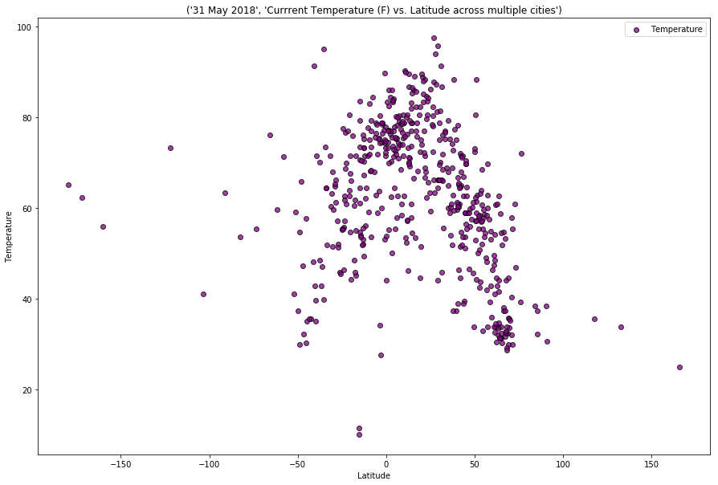

```python
# Plot scatter plot with Temperature (F) vs. Latitude and save as .png

plt.figure(figsize=(15,10))
plt.scatter(cityname1["Latitude"], cityname1["Temperature"], marker="o", facecolors="purple", edgecolors="black",
    alpha=0.75)
plt.legend()
templatChartTitle = CurDate, "Currrent Temperature (F) vs. Latitude across multiple cities"

# Included a horizontal line at y = 0 to depict Equator

# plt.axvline(y=0, color='r', linestyle='-')
plt.title(templatChartTitle)
plt.ylabel("Temperature")
plt.xlabel("Latitude")

plt.savefig('TempLatChartTitle.png')
```

In the scatter plot below, the humidity vs Latitude is depicted to check the spread.

## Conclusion: Since it is summer, the humidity is high for majority of the cities

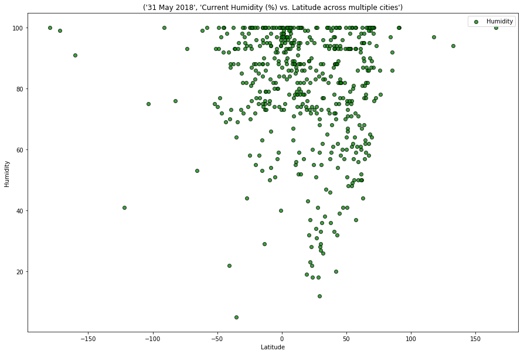

```python
# Plot scatter plot with Humidity (%) vs. Latitude and save as .png

plt.figure(figsize=(15,10))
plt.scatter(cityname1["Latitude"], cityname1["Humidity"], marker="o", facecolors="green", edgecolors="black",
            alpha=0.75)
plt.legend()
# plt.axvline(y=0, color='r', linestyle='-')
HumLatChartTitle = CurDate, "Current Humidity (%) vs. Latitude across multiple cities"
plt.title(HumLatChartTitle)
plt.ylabel("Humidity")
plt.xlabel("Latitude")
plt.savefig('HumLatChartTitle.png')
```

In the scatter plot below, the cloudiness vs Latitude is depicted to check the spread.

## Conclusion: There is no pattern in the spread of clouds

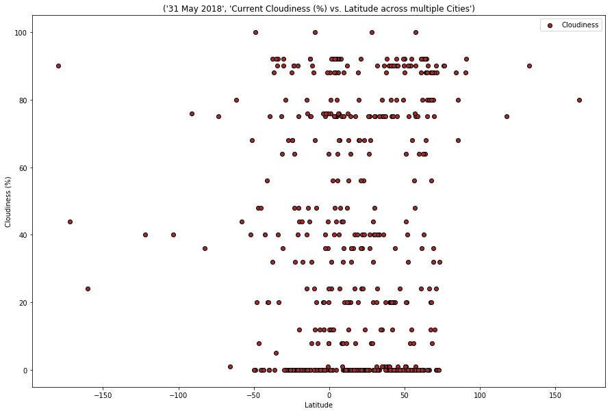

```python
# Plot scatter plot with Cloudiness (%) vs. Latitude and save as .png

plt.figure(figsize=(15,10))
plt.scatter(cityname1["Latitude"], cityname1["Cloudiness"], marker="o", facecolors="brown", edgecolors="black",
            alpha=1)
plt.legend()
# plt.axvline(y=0, color='r', linestyle='-')
ClouLatChartTitle = CurDate, "Current Cloudiness (%) vs. Latitude across multiple Cities"
plt.title(ClouLatChartTitle)
plt.ylabel("Cloudiness (%)")
plt.xlabel("Latitude")
plt.savefig('ClouLatChartTitle.png')
```

In the scatter plot below, the wind speed vs latitude is depicted to check the spread.

## Conclusion: The wind spead is on the lower limit for majority of the cities

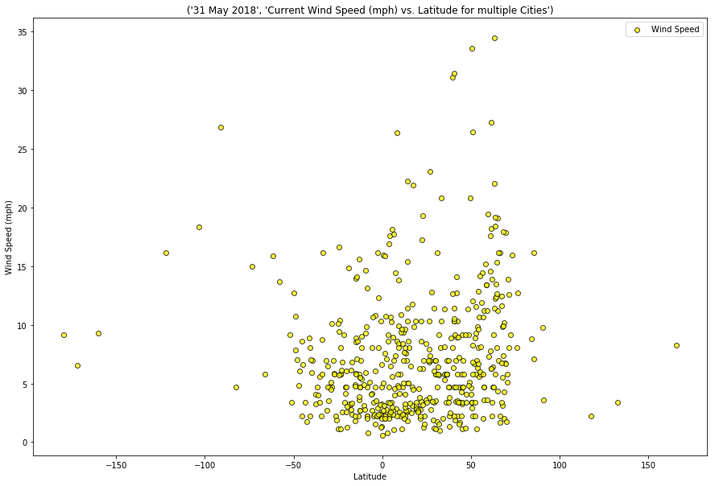

```python
# Plot scatter plot with Wind Speed (mph) vs. Latitude and save as .png

plt.figure(figsize=(15,10))
plt.scatter(cityname1["Latitude"], cityname1["Wind Speed"], marker="o", facecolors="yellow", edgecolors="black",
            alpha=0.75)
plt.legend()
# plt.axvline(y=0, color='r', linestyle='-')
WindLatChartTitle = CurDate, "Current Wind Speed (mph) vs. Latitude for multiple Cities"
plt.title(WindLatChartTitle)
plt.ylabel("Wind Speed (mph)")
plt.xlabel("Latitude")
plt.savefig('WindLatChartTitle.png')
```

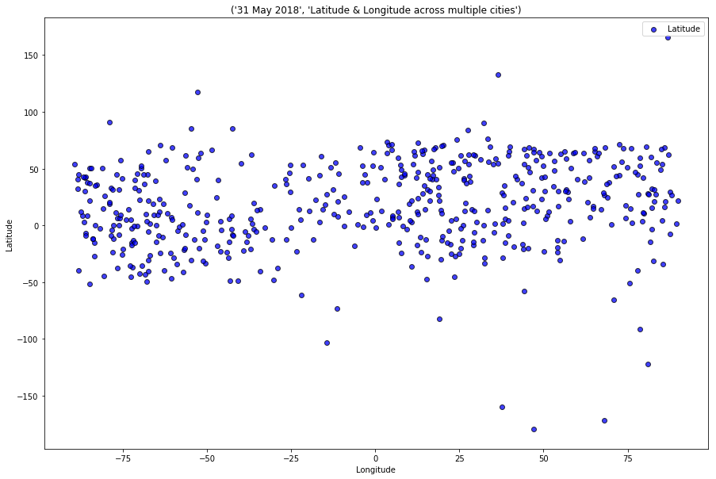

```python
# Plot scatter plot with Longitude vs. Latitude to check city spread and save as .png

plt.figure(figsize=(15,10))
plt.scatter(cityname1["Longitude"], cityname1["Latitude"], marker="o", facecolors="blue", edgecolors="black",
            alpha=0.75)
plt.legend()
# plt.axvline(y=0, color='r', linestyle='-')
LatLonChartTitle = CurDate, "Latitude & Longitude across multiple cities"
plt.title(LatLonChartTitle)
plt.ylabel("Latitude")
plt.xlabel("Longitude")
plt.savefig('LatLonChartTitle.png')
```